# Modellering af konverteringsadfærd

Maskinrummet bag betalingsrækken

Niklas Lehmann Jensen

## Introduktion

#### Hvor vi er: fra produkt til pris

- **Kapitel 5:** produktet og konverteringsretten
- **Kapitel 6:** låntageradfærd → forventede cash flows
- **Kapitel 7:** cash flows → pris, OAS og risikomål

#### Dagens spørgsmål

- Hvordan bliver rentestier og låntageradfærd til forventede cash flows?
- Hvordan hænger $CPR_t$, $ORD_t$, $EXT_t$ og $UDT_t$ sammen?
- Hvorfor reagerer låntagere forskelligt på samme $Gain_t$?
- Hvad er burnout — og hvorfor gør det modellen sti-afhængig?

#### Læringsmål

- Forklare samspillet mellem rentestrukturmodel og prepaymentmodel
- Beregne $CPR_t$, $EXT_t$ og $UDT_t$ pr. termin
- Bruge CK95 og CK92 til henholdsvis facit og låntagerfordeling
- Skelne gevinstkrav-modellen fra mikstur-modellen
- Forklare $LYS$, $Gain_t$, burnout og sti-afhængighed

## Konvertering ændrer betalingsrækken

#### Investoren ejer ikke én fast betalingsrække

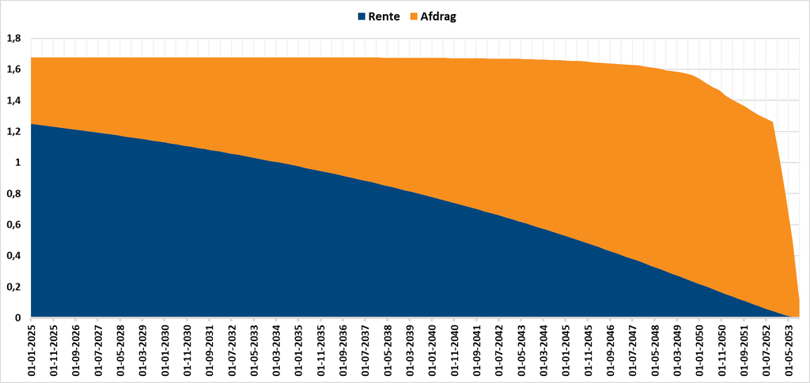

Uden ekstraordinær konvertering

**Officiel:** renter + ordinære afdrag frem mod 2053

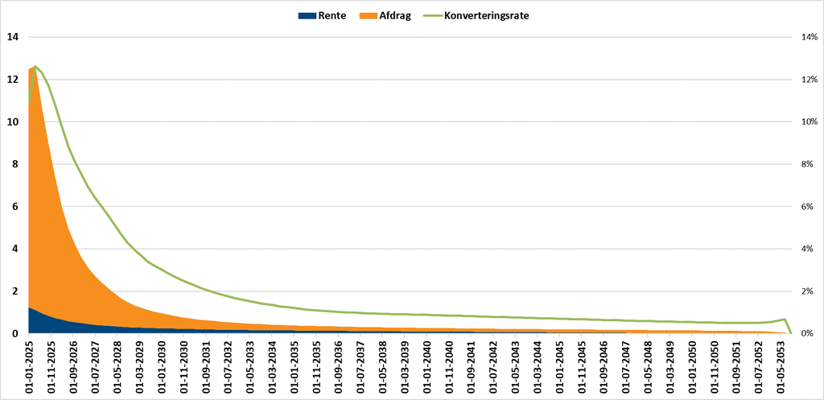

Med modelestimeret konvertering

**Model:** store hovedstolsbetalinger flyttes frem

#### Renten flytter konverteringen mellem kuponrækker

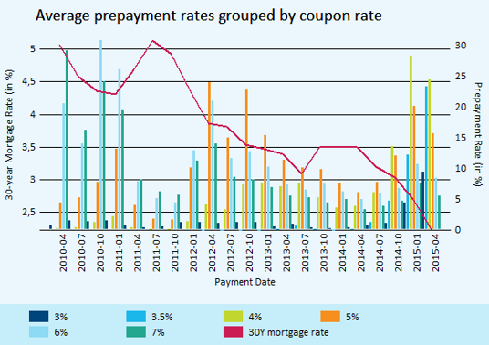

- Rente ned → gamle lån dyrere → incitament op
- Kupon under realkreditrenten → typisk kurs under 100 → næsten intet pari-udtræk
- Grupper, omkostninger og historik ændrer reaktionen

#### To modeller skaber mange betalingsrækker

**Rentestrukturmodel**

- Starter i dagens initielle kurve
- Skaber mange mulige fremtidige rentetilstande

**Prepaymentmodel**

- Omsætter refinansieringsmuligheder til låntageradfærd
- Giver $CPR_t$, $UDT_t$ og cash flow på hver sti

**Indsigt**

Samspillet giver **mange mulige betalingsrækker** — ikke én prognose.

## Rentestier og modeltilstand

#### Én startrente bliver til mange mulige stier

$$r_{t+1}=r_t+\kappa(\theta-r_t)+\varepsilon_{t+1}$$

[figure not shown]

#### Konverteringsmotoren bygger cash flowet led for led

- Rentesti → $Gain_t$ → $CPR_t$ → $UDT_t$ → cash flow

[figure not shown]

#### Renten alene beskriver ikke tilstanden

**Indsigt**

$$S_t=\bigl(r_t, Burnout_t, w_{1,t},\ldots,w_{J,t}\bigr)$$

To stier kan ende i samme rente — men med forskellig låntagerpulje og derfor forskellig forventet $CPR_t$.

- Kort version: modellen skal mindst huske $(t,r_t,Burnout_t)$

## Fra CPR til samlet udtræk

#### CPR måles efter det ordinære afdrag

**Definition**

- $ORD_t$: ordinært udtræk
- $EXT_t$: ekstraordinært udtræk
- $CPR_t$: konverteringsrate på den del, der overlever $ORD_t$
- $UDT_t$: samlet udtræk = ordinært + ekstraordinært

$$EXT_t=CPR_t(1-ORD_t)$$
$$UDT_t=ORD_t+EXT_t=ORD_t+CPR_t(1-ORD_t)$$

#### En kvartalsvis CPR på 3% giver 3,388% samlet udtræk

Med $ORD_t=0{,}004$ og $CPR_t=0{,}030$:

$$UDT_t=0{,}004+0{,}030(1-0{,}004)=0{,}03388$$

$$CPR^{\text{år}}=1-(1-CPR)^4=1-(1-0{,}03)^4\approx 11{,}5\%$$

- **3% pr. kvartal er ikke 3% pr. år**

## Konverteringsdata

#### CK95 er facit — modelestimatet kommer før facit

| Pr. 01/10/2024 | NYK 5% 2053 | NYK 4% 2053 |
| --- | --- | --- |
| Cirk. nom. (mio. kr.) | 62.096,027 | 43.832,959 |
| Udtrukket beløb (mio. kr.) | 2.155,258 | 148,166 |
| Udtræk | 3,47% | 0,34% |
| Ekstraordinært | 3,06% | 0,01% |
| Ordinært (beregnet) | 0,41% | 0,33% |
| **Faktisk CPR (beregnet)** | **3,07%** | **0,01%** |
| **Modelestimat for CPR** | **10,92%** | **2,77%** |

#### CK92 viser, hvem der ligger i serien

| Interval | Lånestørrelse | Gruppe |
| --- | --- | --- |
| 1 | 0–200 t. | Små |
| 2 | 200–500 t. | Små |
| 3 | 500 t.–1 mio. | Små |
| 4 | 1–3 mio. | Mellem |
| 5 | 3–10 mio. | Mellem |
| 6 | 10–50 mio. | Store |
| 7 | over 50 mio. | Store |

For 5% NYK 2053:

| Gruppe | Vægt |
| --- | --- |
| Små | 16,2% |
| Mellem | 82,3% |
| Store | 1,5% |

Store lån reagerer typisk hurtigere: faste omkostninger fylder mindre, og kronegevinsten er større.

## Konverteringsmodellen

#### Refinansieringskurven er låntagerens reelle alternativ

$$z^{\text{refi}}_{\tau}=z^{\text{swap}}_{\tau}+LYS_{\tau}$$

$$Gain_t=\frac{PV_{\text{continue},t}-100(1+cost_t)}{PV_{\text{continue},t}}$$

$$LYS\uparrow\Rightarrow z^{\text{refi}}\uparrow\Rightarrow PV_{\text{continue}}\downarrow\Rightarrow Gain_t\downarrow\Rightarrow CPR_t\downarrow$$

#### LYS, OAS og bidrag bor tre forskellige steder

**Indsigt**

- **LYS:** låntagerspænd på swap → refinansieringskurve → $Gain_t$ → $CPR_t$
- **OAS:** investorspænd i diskonteringen → modelpris = markedskurs (kapitel 7)
- **Bidrag:** betaling fra låntager til institut — ikke et obligationscash flow

$$\text{LYS ændrer hvilke betalinger} \qquad \text{OAS ændrer hvad de er værd}$$

#### Positiv Gain er ikke en automatisk konverteringsbeslutning

- $Gain_t>0$ siger kun, at konvertering **nu** har positiv økonomisk gevinst

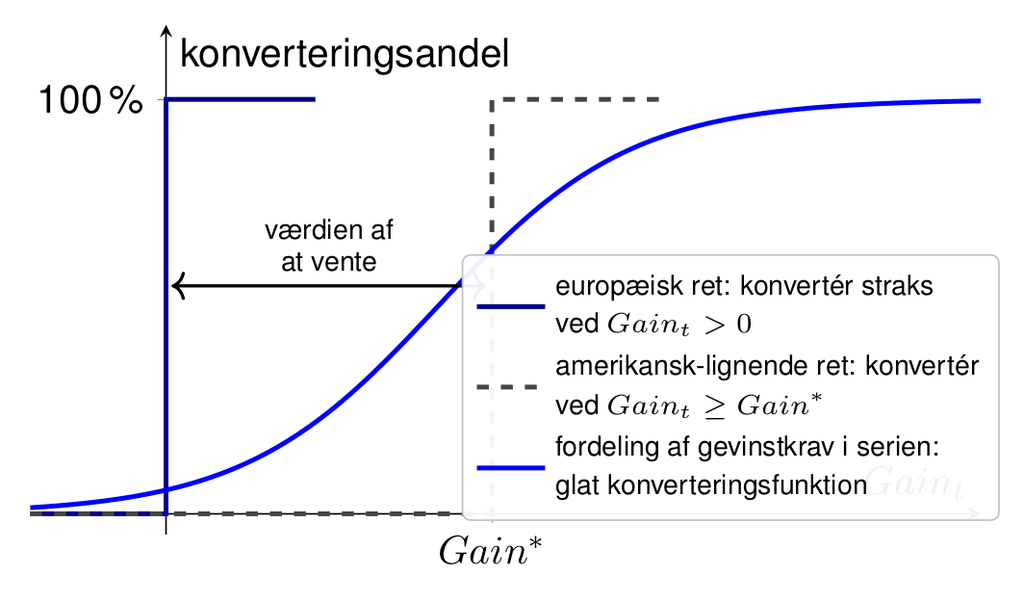

#### Den logistiske funktion oversætter indeks til sandsynlighed

[figure not shown]

$$\Lambda(\eta)=\frac{1}{1+e^{-\eta}}$$

- Output ligger altid mellem 0 og 1
- Langsomt → hurtigt → fladt
- Passer til en fordeling af gevinstkrav

#### Gevinstkrav-modellen giver CPR for hver gruppe

$$\eta_{j,t}=\alpha_j+\beta_{G,j}Gain_t+\beta_{B,j}Burnout_{t-1}$$

$$CPR_{j,t}=\Lambda(\eta_{j,t})$$

**Definition**

Konverteringsbeslutningen på termin $t$ bruger puljen ved periodens begyndelse, $Burnout_{t-1}$. Først bagefter opdateres $Burnout_t$.

#### Først gruppekurver — derefter seriens CPR

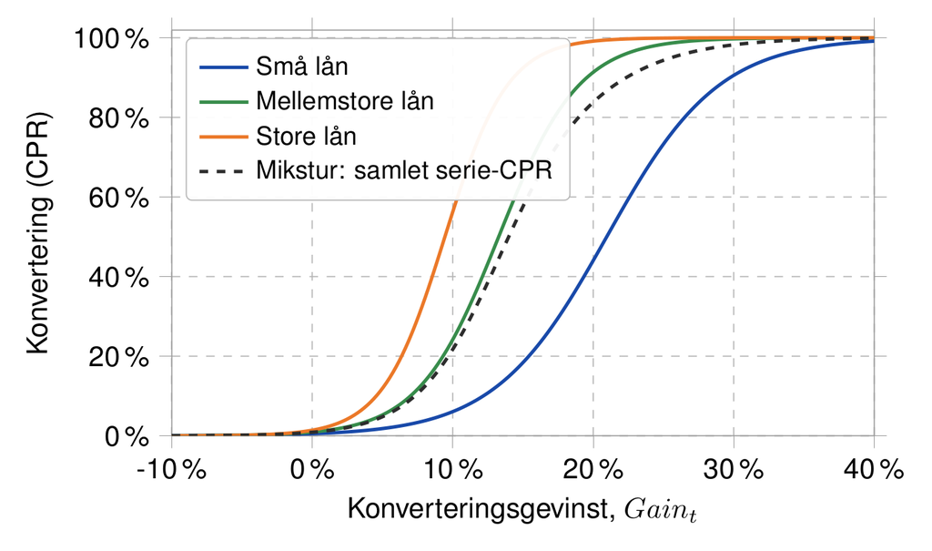

- Ved samme $Gain_t$: store lån reagerer hurtigst
- Rentebevægelsen flytter os langs kurverne

$$CPR_t=\sum_{j=1}^{J}w_{j,t}CPR_{j,t}$$

**Mikstur-modellen:** serien er et vægtet gennemsnit af grupperne.

## Burnout og modelhukommelse

#### De hurtige låntagere forlader serien først

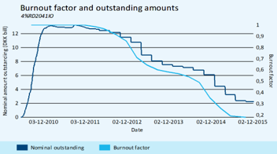

For en lukket serie:

$$Burnout_t=Burnout_{t-1}(1-CPR_t)$$

- Høj værdi = mange aktive låntagere tilbage
- Høj CPR i dag → lavere aktiv pulje i morgen
- Nyudstedelser kan gøre en åben serie friskere

#### Samme rente kan give forskellig senere CPR

| Rentesti | Tidligere konvertering | Senere CPR ved samme rente |
| --- | --- | --- |
| Renten faldt tidligt | Mange aktive låntagere er væk | Lavere CPR |
| Renten faldt ikke tidligt | Flere aktive låntagere er tilbage | Højere CPR |

**Indsigt**

Sti-afhængighed betyder, at modellens tilstand er **rente plus låntagerpulje**.

#### Én termin gennem motoren

Med $Gain_t=0{,}04$, $Burnout_{t-1}=0{,}90$, $ORD_t=0{,}004$ og vægte $(0{,}162;0{,}823;0{,}015)$:

| Gruppe | $CPR_{j,t}$ |
| --- | --- |
| Små | 1,4% |
| Mellem | 3,6% |
| Store | 7,6% |

$$CPR_t\approx 0{,}033 \qquad UDT_t\approx 0{,}037 \qquad Burnout_t\approx 0{,}870$$

- Store lån reagerer mest, men mellemgruppen driver serien, fordi den vejer **82,3%**.

## Fra model til pris

#### Modellen er et kvalificeret bud — ikke et facit

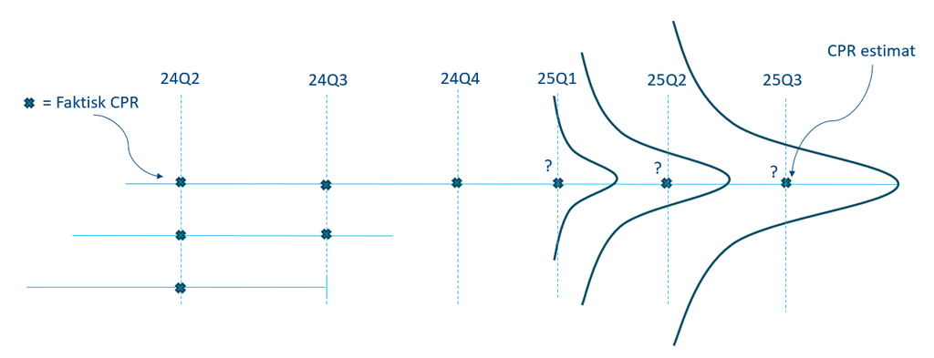

- CK95 viser nye realiserede udtræk
- CK92 viser den opdaterede låntagerpulje
- Parametre genkalibreres, når adfærden flytter sig
- Flere rentestier og adfærdsudfald → større usikkerhed med horisonten

#### Renten rammer både cash flow og diskontering

På sti $m$:
$$CF^{(m)}_1,CF^{(m)}_2,\ldots,CF^{(m)}_T$$

$$P_{\text{model}}=\sum_{m=1}^{M}\pi_m\sum_{t=1}^{T}DF_t^{(m)}CF_t^{(m)}$$

**Kapitel 7**

Man kan ikke først gennemsnitliggøre cash flows og bagefter diskontere med dagens kurve. $CF$ og $DF$ bevæger sig sammen på hver sti; OAS lægges på **investorens diskontering**.

## Afrunding

#### The Takeaways

1. Rentesti + refinansieringskurve (swap + **LYS**) driver $Gain_t\rightarrow CPR_t\rightarrow UDT_t\rightarrow$ cash flow.
2. **CK95** viser faktisk udtræk; **CK92** viser, hvem der ligger i serien.
3. Gevinstkrav-modellen giver gruppe-CPR; mikstur-modellen vægter grupperne til serie-CPR.
4. Burnout husker den aktive pulje og gør modellen **sti-afhængig**.

## Øvelser

#### Øvelse 1: En simpel rentemodel

Med $r_0=3{,}0\%$, $\theta=2{,}0\%$ og $\kappa=0{,}3$:

1. Beregn $r_1$, når $\varepsilon_1=0$.
2. Beregn $r_1$ for $\varepsilon_1=+0{,}5\%$ og $-0{,}5\%$.
3. Fortolk $\kappa=0$ og $\kappa=1$.
4. Hvorfor skaber stødene mange mulige betalingsrækker?

#### Øvelse 2: CK95 og udtræk

|  | 1,5 RD S MTG 2043 | 5 NYK E MTG 2053 |
| --- | --- | --- |
| Cirk. nom. (mio. kr.) | 21.371,745 | 63.871,157 |
| Udtrukket beløb (mio. kr.) | 263,450 | 1.751,177 |
| Ekstraordinært | 0,00% | 2,34% |
| Udtræk | 1,23% | 2,74% |

1. Beregn $ORD_t$ og $CPR_t$ for begge serier.
2. 1,5 RD handler i kurs 85; 5 NYK i kurs 102. Forklar forskellen i pari-udtræk.

#### Øvelse 3: CK92 og gruppevægte

Brug intervalgrupperingen:

- 1–3 = små lån
- 4–5 = mellemstore lån
- 6–7 = store lån
1. Gruppér de udleverede CK92-beløb for begge obligationer.
2. Beregn $w_{1,t}$, $w_{2,t}$ og $w_{3,t}$.
3. Hvilken serie forventes at reagere hurtigst — og hvorfor?

#### Øvelse 4: Gain og beslutningen

$$Gain_t=\frac{PV_{\text{continue},t}-100(1+cost_t)}{PV_{\text{continue},t}}$$

1. Beregn Gain for $PV_{continue}=110{,}28$ og $cost=0{,}05$.
2. Gentag for $PV_{continue}=101{,}00$.
3. Sæt derefter $cost=0{,}02$.
4. Forklar, hvorfor $Gain_t>0$ ikke nødvendigvis betyder konvertering nu.

#### Øvelse 5: Den logistiske funktion

$$\Lambda(\eta)=\frac{1}{1+e^{-\eta}}$$

1. Beregn $\Lambda(-2)$, $\Lambda(0)$ og $\Lambda(2)$.
2. Hvorfor ligger output altid mellem 0 og 1?
3. Forklar S-formen som en fordeling af låntagernes gevinstkrav.
4. Hvorfor ligger den rationelle tærskel for en genanvendelig ret over nul?

#### Øvelse 6: Logistisk CPR og mikstur

Givet gruppe-CPR $1{,}43\%$, $3{,}27\%$, $7{,}64\%$ og nominelle beløb:

$$N_1=9.853.758.008,\quad N_2=50.505.834.785,\quad N_3=895.702.869$$

1. Beregn gruppevægtene og seriens samlede $CPR_t$.
2. Hvad sker der typisk med $Gain_t$ og $CPR_t$, når renten falder?
3. Hvorfor kan store lån have højere CPR ved samme Gain?

#### Øvelse 7: Burnout og sti-afhængighed

En lukket serie har $Burnout_{t-1}=0{,}95$.

1. Beregn $Burnout_t$ ved $CPR_t=0{,}03$ og $0{,}15$.
2. Hvorfor kan høj CPR i dag sænke fremtidig CPR?
3. To stier ender i samme rente om to år; kun den ene havde et tidligt rentefald. Hvorfor kan senere CPR være forskellig?